# Human Activity Recognition

Manuel A. Vázquez

22 de noviembre de 2015

The goal of this work is to predict the kind of activity being performed by a person from measurements obtained by wearable devices. More information is provided in http://groupware.les.inf.puc-rio.br/har.

The R libraries used in this analysis are loaded.

# Data loading

```r
training <- read.csv('pml-training.csv')
testing <- read.csv('pml-testing.csv')
```

The first variable in the data (both training and testing) is just the number of rows, so it does not serve any purpose.

```r
training <- training %>% select(-X)
testing <- testing %>% select(-X)
```

# Data partitioning

The given training set is, in turn, split into *training* and *test* sets.

```r
inTrain = createDataPartition(training$classe, p = 0.7,list=FALSE)
my.training <- training[inTrain,]
my.testing <- training[-inTrain,]
```

# Data preprocessing

Some variables are almost constant across all the observations, and hence are not useful for discriminating among classes. We identify them and remove them.

```r
near.zero <- nearZeroVar(my.training,saveMetrics=TRUE)
near.zero.vars <- rownames(near.zero)[near.zero$nzv]
my.training <- my.training %>% dplyr::select(-one_of(near.zero.vars))
my.testing <- my.testing %>% dplyr::select(-one_of(near.zero.vars))
```

Variables with majority of *NA*s are not of interest.

```r
na.percentages <- sapply(my.training, function(x) mean(is.na(x)))
near.all.na.vars <- attr(which(na.percentages > 0.95),"names")
my.training <- my.training %>% dplyr::select(-one_of(near.all.na.vars))
my.testing <- my.testing %>% dplyr::select(-one_of(near.all.na.vars))
```

# Exploratory data analysis

Three potential useful features are explored visually.

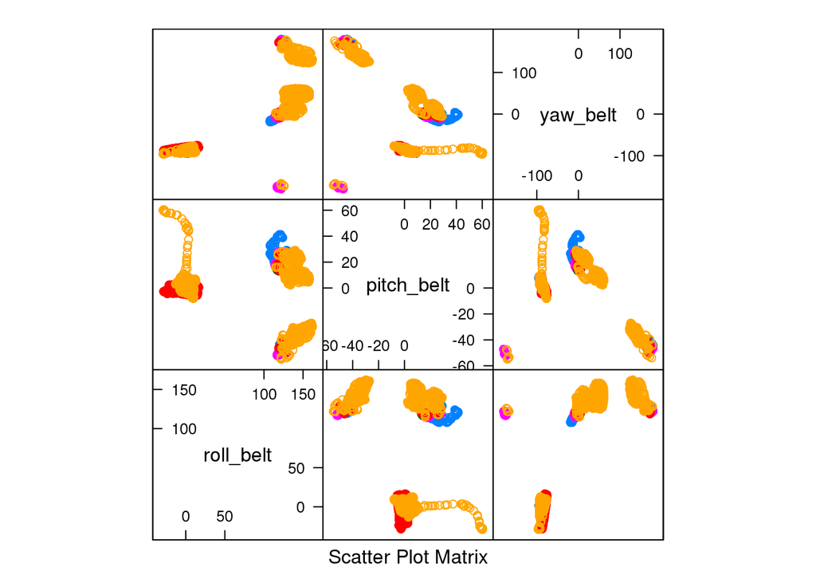

```r
featurePlot(x = my.training[,c("roll_belt","pitch_belt","yaw_belt")],y = my.training$classe,plot = "pairs")
```

The clouds of points seem *separable*, but not linearly.

# Machine learning

*Random forests* is a powerful non-linear method, which might work with this dataset. We are going to train our model using cross-validation.

```r
train.ctrl <- trainControl(method="cv", allowParallel=TRUE)
modFit <- train(x = my.training[,c("roll_belt","pitch_belt","yaw_belt")],y = my.training$classe,method="rf",trControl=train.ctrl)
```

A rough estimation of the accuracy of our predictor can be obtained as

```r
mean(predict(modFit,my.testing[,1:57]) == my.testing$classe)
```

```
## [1] 0.8618522
```